# Optimal Treatment Analysis

## Outcome Variable

**Outcome Variable:** ever_stunted

## Predictor Variables

**Intervention Variable:** fhtcm

**Adjustment Set:**

- arm
- W_mage
- W_fage
- meducyrs
- feducyrs
- W_mhtcm
- W_mwtkg
- W_mbmi
- single
- delta_W_mage
- delta_W_fage
- delta_meducyrs
- delta_feducyrs
- delta_W_mhtcm
- delta_W_mwtkg
- delta_W_mbmi
- delta_single

## Stratifying Variables

The analysis was stratified on these variable(s):

- agecat
- studyid
- country

## Data Summary

| agecat | studyid | country | fhtcm | ever_stunted | n_cell | n |
| --- | --- | --- | --- | --- | --- | --- |
| 0-24 months | ki1000304b-SAS-CompFeed | INDIA | >=167 cm | 0 | 137 | 907 |
| 0-24 months | ki1000304b-SAS-CompFeed | INDIA | >=167 cm | 1 | 273 | 907 |
| 0-24 months | ki1000304b-SAS-CompFeed | INDIA | <162 cm | 0 | 50 | 907 |
| 0-24 months | ki1000304b-SAS-CompFeed | INDIA | <162 cm | 1 | 180 | 907 |
| 0-24 months | ki1000304b-SAS-CompFeed | INDIA | [162-167) cm | 0 | 69 | 907 |
| 0-24 months | ki1000304b-SAS-CompFeed | INDIA | [162-167) cm | 1 | 198 | 907 |
| 0-24 months | ki1000304b-SAS-FoodSuppl | INDIA | >=167 cm | 0 | 23 | 399 |
| 0-24 months | ki1000304b-SAS-FoodSuppl | INDIA | >=167 cm | 1 | 83 | 399 |
| 0-24 months | ki1000304b-SAS-FoodSuppl | INDIA | <162 cm | 0 | 15 | 399 |
| 0-24 months | ki1000304b-SAS-FoodSuppl | INDIA | <162 cm | 1 | 148 | 399 |
| 0-24 months | ki1000304b-SAS-FoodSuppl | INDIA | [162-167) cm | 0 | 23 | 399 |
| 0-24 months | ki1000304b-SAS-FoodSuppl | INDIA | [162-167) cm | 1 | 107 | 399 |
| 0-24 months | ki1101329-Keneba | GAMBIA | >=167 cm | 0 | 598 | 1929 |
| 0-24 months | ki1101329-Keneba | GAMBIA | >=167 cm | 1 | 647 | 1929 |
| 0-24 months | ki1101329-Keneba | GAMBIA | <162 cm | 0 | 52 | 1929 |
| 0-24 months | ki1101329-Keneba | GAMBIA | <162 cm | 1 | 80 | 1929 |
| 0-24 months | ki1101329-Keneba | GAMBIA | [162-167) cm | 0 | 207 | 1929 |
| 0-24 months | ki1101329-Keneba | GAMBIA | [162-167) cm | 1 | 345 | 1929 |
| 0-24 months | ki1119695-PROBIT | BELARUS | >=167 cm | 0 | 9839 | 12537 |
| 0-24 months | ki1119695-PROBIT | BELARUS | >=167 cm | 1 | 1905 | 12537 |
| 0-24 months | ki1119695-PROBIT | BELARUS | <162 cm | 0 | 119 | 12537 |
| 0-24 months | ki1119695-PROBIT | BELARUS | <162 cm | 1 | 49 | 12537 |
| 0-24 months | ki1119695-PROBIT | BELARUS | [162-167) cm | 0 | 474 | 12537 |
| 0-24 months | ki1119695-PROBIT | BELARUS | [162-167) cm | 1 | 151 | 12537 |
| 0-24 months | ki1135781-COHORTS | GUATEMALA | >=167 cm | 0 | 16 | 496 |
| 0-24 months | ki1135781-COHORTS | GUATEMALA | >=167 cm | 1 | 48 | 496 |
| 0-24 months | ki1135781-COHORTS | GUATEMALA | <162 cm | 0 | 24 | 496 |
| 0-24 months | ki1135781-COHORTS | GUATEMALA | <162 cm | 1 | 269 | 496 |
| 0-24 months | ki1135781-COHORTS | GUATEMALA | [162-167) cm | 0 | 24 | 496 |
| 0-24 months | ki1135781-COHORTS | GUATEMALA | [162-167) cm | 1 | 115 | 496 |

[output cut: 60 more lines]

The following strata were considered:

- agecat: 0-24 months, studyid: ki1000304b-SAS-CompFeed, country: INDIA
- agecat: 0-24 months, studyid: ki1000304b-SAS-FoodSuppl, country: INDIA
- agecat: 0-24 months, studyid: ki1101329-Keneba, country: GAMBIA
- agecat: 0-24 months, studyid: ki1119695-PROBIT, country: BELARUS
- agecat: 0-24 months, studyid: ki1135781-COHORTS, country: GUATEMALA
- agecat: 0-6 months, studyid: ki1000304b-SAS-CompFeed, country: INDIA
- agecat: 0-6 months, studyid: ki1000304b-SAS-FoodSuppl, country: INDIA
- agecat: 0-6 months, studyid: ki1101329-Keneba, country: GAMBIA
- agecat: 0-6 months, studyid: ki1119695-PROBIT, country: BELARUS
- agecat: 0-6 months, studyid: ki1135781-COHORTS, country: GUATEMALA
- agecat: 6-24 months, studyid: ki1000304b-SAS-CompFeed, country: INDIA
- agecat: 6-24 months, studyid: ki1000304b-SAS-FoodSuppl, country: INDIA
- agecat: 6-24 months, studyid: ki1101329-Keneba, country: GAMBIA
- agecat: 6-24 months, studyid: ki1119695-PROBIT, country: BELARUS
- agecat: 6-24 months, studyid: ki1135781-COHORTS, country: GUATEMALA

## Methods Detail

We’re interested in the causal parameters $E[Y_a]$ for all values of $a \in \mathcal{A}$. These parameters represent the mean outcome if, possibly contrary to fact, we intervened to set all units to have $A=a$. Under the randomization and positivity assumptions, these are identified by the statistical parameters $\psi_a=E_W[E_{Y|A,W}(Y|A=a,W)]$. In addition, we’re interested in the mean of $Y$, $E[Y]$ under no intervention (the observed mean). We will estimate these parameters by using SuperLearner to fit the relevant likelihood factors – $E_{Y|A,W}(Y|A=a,W)$ and $p(A=a|W)$, and then updating our likelihood fit using a joint TMLE.

For unadjusted analyses ($W=\{\}$), initial likelihoods were estimated using Lrnr_glm to estimate the simple $E(Y|A)$ and Lrnr_mean to estimate $p(A)$. For adjusted analyses, a small library containing Lrnr_glmnet, Lrnr_xgboost, and Lrnr_mean was used.

Having estimated these parameters, we will then use the delta method to estimate relative risks and attributable risks relative to a prespecified baseline level of $A$.

# Results Detail

## Results Plots

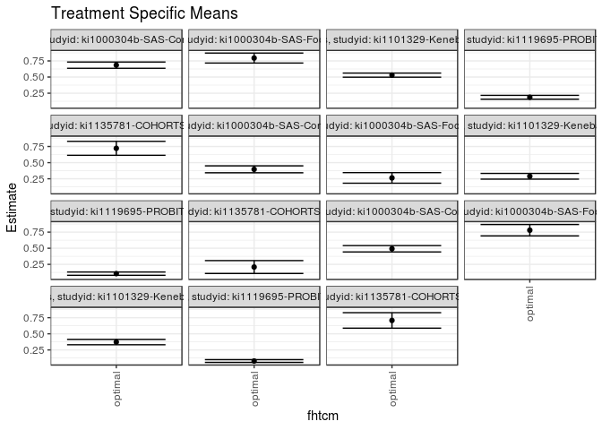

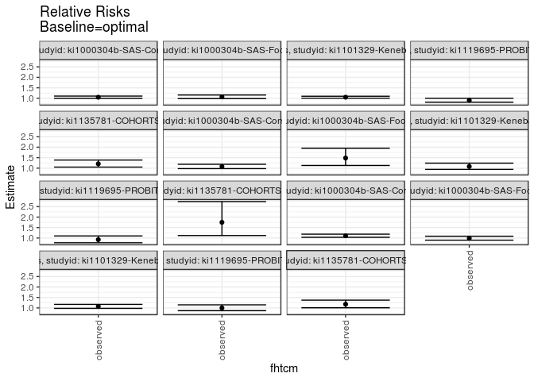

## Results Table

### Parameter: TSM

| agecat | studyid | country | intervention_level | baseline_level | estimate | ci_lower | ci_upper |
| --- | --- | --- | --- | --- | --- | --- | --- |
| 0-24 months | ki1000304b-SAS-CompFeed | INDIA | optimal | NA | 0.6844789 | 0.6360191 | 0.7329388 |
| 0-24 months | ki1000304b-SAS-FoodSuppl | INDIA | optimal | NA | 0.7942820 | 0.7168562 | 0.8717079 |
| 0-24 months | ki1101329-Keneba | GAMBIA | optimal | NA | 0.5297954 | 0.4976973 | 0.5618935 |
| 0-24 months | ki1119695-PROBIT | BELARUS | optimal | NA | 0.1864960 | 0.1566630 | 0.2163291 |
| 0-24 months | ki1135781-COHORTS | GUATEMALA | optimal | NA | 0.7218297 | 0.6132834 | 0.8303760 |
| 0-6 months | ki1000304b-SAS-CompFeed | INDIA | optimal | NA | 0.3964468 | 0.3427979 | 0.4500956 |
| 0-6 months | ki1000304b-SAS-FoodSuppl | INDIA | optimal | NA | 0.2631692 | 0.1813401 | 0.3449982 |
| 0-6 months | ki1101329-Keneba | GAMBIA | optimal | NA | 0.2886756 | 0.2443080 | 0.3330433 |
| 0-6 months | ki1119695-PROBIT | BELARUS | optimal | NA | 0.1059071 | 0.0803052 | 0.1315089 |
| 0-6 months | ki1135781-COHORTS | GUATEMALA | optimal | NA | 0.2084854 | 0.1087722 | 0.3081985 |
| 6-24 months | ki1000304b-SAS-CompFeed | INDIA | optimal | NA | 0.4916908 | 0.4426075 | 0.5407740 |
| 6-24 months | ki1000304b-SAS-FoodSuppl | INDIA | optimal | NA | 0.7793146 | 0.6909766 | 0.8676526 |
| 6-24 months | ki1101329-Keneba | GAMBIA | optimal | NA | 0.3720794 | 0.3307379 | 0.4134210 |
| 6-24 months | ki1119695-PROBIT | BELARUS | optimal | NA | 0.0782081 | 0.0569954 | 0.0994208 |
| 6-24 months | ki1135781-COHORTS | GUATEMALA | optimal | NA | 0.7073733 | 0.5873760 | 0.8273707 |

### Parameter: E(Y)

| agecat | studyid | country | intervention_level | baseline_level | estimate | ci_lower | ci_upper |
| --- | --- | --- | --- | --- | --- | --- | --- |
| 0-24 months | ki1000304b-SAS-CompFeed | INDIA | observed | NA | 0.7177508 | 0.6751525 | 0.7603491 |
| 0-24 months | ki1000304b-SAS-FoodSuppl | INDIA | observed | NA | 0.8471178 | 0.8117623 | 0.8824733 |
| 0-24 months | ki1101329-Keneba | GAMBIA | observed | NA | 0.5557284 | 0.5335489 | 0.5779078 |
| 0-24 months | ki1119695-PROBIT | BELARUS | observed | NA | 0.1679030 | 0.1492221 | 0.1865839 |
| 0-24 months | ki1135781-COHORTS | GUATEMALA | observed | NA | 0.8709677 | 0.8414356 | 0.9004999 |
| 0-6 months | ki1000304b-SAS-CompFeed | INDIA | observed | NA | 0.4265193 | 0.3923837 | 0.4606550 |
| 0-6 months | ki1000304b-SAS-FoodSuppl | INDIA | observed | NA | 0.3904282 | 0.3423793 | 0.4384771 |
| 0-6 months | ki1101329-Keneba | GAMBIA | observed | NA | 0.3116657 | 0.2897893 | 0.3335421 |
| 0-6 months | ki1119695-PROBIT | BELARUS | observed | NA | 0.0976310 | 0.0843265 | 0.1109356 |
| 0-6 months | ki1135781-COHORTS | GUATEMALA | observed | NA | 0.3649852 | 0.3135088 | 0.4164615 |
| 6-24 months | ki1000304b-SAS-CompFeed | INDIA | observed | NA | 0.5441478 | 0.5023342 | 0.5859615 |
| 6-24 months | ki1000304b-SAS-FoodSuppl | INDIA | observed | NA | 0.7689076 | 0.7152410 | 0.8225741 |
| 6-24 months | ki1101329-Keneba | GAMBIA | observed | NA | 0.3977695 | 0.3716030 | 0.4239360 |
| 6-24 months | ki1119695-PROBIT | BELARUS | observed | NA | 0.0779232 | 0.0640302 | 0.0918162 |
| 6-24 months | ki1135781-COHORTS | GUATEMALA | observed | NA | 0.8306452 | 0.7924799 | 0.8688104 |

### Parameter: RR

| agecat | studyid | country | intervention_level | baseline_level | estimate | ci_lower | ci_upper |
| --- | --- | --- | --- | --- | --- | --- | --- |
| 0-24 months | ki1000304b-SAS-CompFeed | INDIA | observed | optimal | 1.0486091 | 0.9965384 | 1.1034006 |
| 0-24 months | ki1000304b-SAS-FoodSuppl | INDIA | observed | optimal | 1.0665202 | 0.9840391 | 1.1559147 |
| 0-24 months | ki1101329-Keneba | GAMBIA | observed | optimal | 1.0489490 | 1.0033031 | 1.0966717 |
| 0-24 months | ki1119695-PROBIT | BELARUS | observed | optimal | 0.9003034 | 0.8116867 | 0.9985949 |
| 0-24 months | ki1135781-COHORTS | GUATEMALA | observed | optimal | 1.2066111 | 1.0502053 | 1.3863103 |
| 0-6 months | ki1000304b-SAS-CompFeed | INDIA | observed | optimal | 1.0758553 | 0.9771300 | 1.1845554 |
| 0-6 months | ki1000304b-SAS-FoodSuppl | INDIA | observed | optimal | 1.4835637 | 1.1273959 | 1.9522522 |
| 0-6 months | ki1101329-Keneba | GAMBIA | observed | optimal | 1.0796398 | 0.9409945 | 1.2387129 |
| 0-6 months | ki1119695-PROBIT | BELARUS | observed | optimal | 0.9218552 | 0.7728500 | 1.0995886 |
| 0-6 months | ki1135781-COHORTS | GUATEMALA | observed | optimal | 1.7506511 | 1.1178799 | 2.7415996 |
| 6-24 months | ki1000304b-SAS-CompFeed | INDIA | observed | optimal | 1.1066871 | 1.0346031 | 1.1837934 |
| 6-24 months | ki1000304b-SAS-FoodSuppl | INDIA | observed | optimal | 0.9866459 | 0.8964533 | 1.0859128 |
| 6-24 months | ki1101329-Keneba | GAMBIA | observed | optimal | 1.0690446 | 0.9780071 | 1.1685564 |
| 6-24 months | ki1119695-PROBIT | BELARUS | observed | optimal | 0.9963578 | 0.8664158 | 1.1457881 |
| 6-24 months | ki1135781-COHORTS | GUATEMALA | observed | optimal | 1.1742670 | 1.0058650 | 1.3708630 |

### Parameter: PAR

| agecat | studyid | country | intervention_level | baseline_level | estimate | ci_lower | ci_upper |
| --- | --- | --- | --- | --- | --- | --- | --- |
| 0-24 months | ki1000304b-SAS-CompFeed | INDIA | optimal | NA | 0.0332719 | -0.0020042 | 0.0685481 |
| 0-24 months | ki1000304b-SAS-FoodSuppl | INDIA | optimal | NA | 0.0528358 | -0.0107129 | 0.1163845 |
| 0-24 months | ki1101329-Keneba | GAMBIA | optimal | NA | 0.0259330 | 0.0023677 | 0.0494982 |
| 0-24 months | ki1119695-PROBIT | BELARUS | optimal | NA | -0.0185930 | -0.0382471 | 0.0010611 |
| 0-24 months | ki1135781-COHORTS | GUATEMALA | optimal | NA | 0.1491380 | 0.0499805 | 0.2482956 |
| 0-6 months | ki1000304b-SAS-CompFeed | INDIA | optimal | NA | 0.0300726 | -0.0077475 | 0.0678927 |
| 0-6 months | ki1000304b-SAS-FoodSuppl | INDIA | optimal | NA | 0.1272590 | 0.0547416 | 0.1997765 |
| 0-6 months | ki1101329-Keneba | GAMBIA | optimal | NA | 0.0229901 | -0.0167363 | 0.0627164 |
| 0-6 months | ki1119695-PROBIT | BELARUS | optimal | NA | -0.0082761 | -0.0271866 | 0.0106344 |
| 0-6 months | ki1135781-COHORTS | GUATEMALA | optimal | NA | 0.1564998 | 0.0617218 | 0.2512777 |
| 6-24 months | ki1000304b-SAS-CompFeed | INDIA | optimal | NA | 0.0524571 | 0.0189122 | 0.0860019 |
| 6-24 months | ki1000304b-SAS-FoodSuppl | INDIA | optimal | NA | -0.0104071 | -0.0850537 | 0.0642396 |
| 6-24 months | ki1101329-Keneba | GAMBIA | optimal | NA | 0.0256901 | -0.0074556 | 0.0588358 |
| 6-24 months | ki1119695-PROBIT | BELARUS | optimal | NA | -0.0002848 | -0.0112365 | 0.0106668 |
| 6-24 months | ki1135781-COHORTS | GUATEMALA | optimal | NA | 0.1232719 | 0.0147073 | 0.2318364 |

### Parameter: PAF

| agecat | studyid | country | intervention_level | baseline_level | estimate | ci_lower | ci_upper |
| --- | --- | --- | --- | --- | --- | --- | --- |
| 0-24 months | ki1000304b-SAS-CompFeed | INDIA | optimal | NA | 0.0463558 | -0.0034737 | 0.0937109 |
| 0-24 months | ki1000304b-SAS-FoodSuppl | INDIA | optimal | NA | 0.0623712 | -0.0162198 | 0.1348843 |
| 0-24 months | ki1101329-Keneba | GAMBIA | optimal | NA | 0.0466648 | 0.0032922 | 0.0881500 |
| 0-24 months | ki1119695-PROBIT | BELARUS | optimal | NA | -0.1107367 | -0.2320025 | -0.0014071 |
| 0-24 months | ki1135781-COHORTS | GUATEMALA | optimal | NA | 0.1712326 | 0.0478053 | 0.2786607 |
| 0-6 months | ki1000304b-SAS-CompFeed | INDIA | optimal | NA | 0.0705070 | -0.0234053 | 0.1558014 |
| 0-6 months | ki1000304b-SAS-FoodSuppl | INDIA | optimal | NA | 0.3259474 | 0.1130002 | 0.4877711 |
| 0-6 months | ki1101329-Keneba | GAMBIA | optimal | NA | 0.0737651 | -0.0627055 | 0.1927104 |
| 0-6 months | ki1119695-PROBIT | BELARUS | optimal | NA | -0.0847690 | -0.2939121 | 0.0905690 |
| 0-6 months | ki1135781-COHORTS | GUATEMALA | optimal | NA | 0.4287840 | 0.1054496 | 0.6352494 |
| 6-24 months | ki1000304b-SAS-CompFeed | INDIA | optimal | NA | 0.0964022 | 0.0334458 | 0.1552580 |
| 6-24 months | ki1000304b-SAS-FoodSuppl | INDIA | optimal | NA | -0.0135349 | -0.1155071 | 0.0791157 |
| 6-24 months | ki1101329-Keneba | GAMBIA | optimal | NA | 0.0645854 | -0.0224875 | 0.1442433 |
| 6-24 months | ki1119695-PROBIT | BELARUS | optimal | NA | -0.0036555 | -0.1541802 | 0.1272383 |
| 6-24 months | ki1135781-COHORTS | GUATEMALA | optimal | NA | 0.1484049 | 0.0058308 | 0.2705325 |